# P8130 hw6

Chenxin Zhang

12/2/2020

# Problem 1

### Problem 1.1 Create a correlation matrix

|  | satisfaction | age | severity | anxiety |
| --- | --- | --- | --- | --- |
| satisfaction | 1.000 | -0.787 | -0.603 | -0.645 |
| age | -0.787 | 1.000 | 0.568 | 0.570 |
| severity | -0.603 | 0.568 | 1.000 | 0.671 |
| anxiety | -0.645 | 0.570 | 0.671 | 1.000 |

### Problem 1.2 Fit a multiple regression model including all three predictors

We conduct the **ANOVA test for MLR**, with the number of predictors of p = 3, and n = 46. Let 1 denotes age, 2 denotes severity, and 3 denotes anxiety

**hypothesis:**

$H_0~:~\beta_1=\beta_2=\beta_3 = 0$

$H_1$ : at least one of the coefficient not equal to 0
The model we fit is:
$$statisfaction=158.4913-1.1416age-0.4420severity-13.4702anxiety$$
**statistics**

$$F = \frac{MSR}{MSE}= \frac{SSR/p}{SSE(n-p-1)}=30.1$$
$F_{1-0.05,3,46-3-1}=2.827$ **Decision Rule** $Reject ~ H_0 ~ if ~ F>F_{1-\alpha,p,n-p-1}$

$Fail ~ reject ~ H_0 ~ if ~F<F_{1-\alpha,p,n-p-1}$

**Interpretation** Since F_statistics equal to 30.1>$F_{1-0.05,3,46-3-1}=2.827$, at 0.05 confidence level, we reject the null hypothesis and conclude that at least one predictor have coefficent not equal to 0.

### Problem 1.3 Show the regression results for all estimated slope coefficients with 95% CIs. Interpret the coefficient and 95% CI associated with ‘severity of illness’.

|  | 2.5 % | 97.5 % |
| --- | --- | --- |
| (Intercept) | 121.91 | 195.071 |
| age | -1.57 | -0.708 |
| severity | -1.44 | 0.551 |
| anxiety | -27.80 | 0.858 |

With one unit change of severity of disease, we are 95% confident that the mean change of patients’ satisfaction score will between -1.44 and 0.551.

### Problem 1.4 Obtain an interval estimate for a new patient’s satisfaction with the following characteristics:Age=35, Severity=42, Anxiety=2.1. Interpret the interval. (2p)

| fit | lwr | upr |
| --- | --- | --- |
| 71.7 | 50.1 | 93.3 |

For a patient with age 35, severity of illness of 42 and anxiety level of 2.1, We are 95% confident that the predicted mean patient’s satisfaction score will between 50.1 nd 93.3.

### Problem 1.5.a) Test whether ‘anxiety level’ can be dropped from the regression model, given the other two covariates are retained.

We use the ANOVA partical F-test in MLR to test whether anxiety level is significant or not in the regression model.

**hypothesis:** $H_0~:~\beta_{anxiety} = 0$

$H_1~:~\beta_{anxiety} \ne 0$

model 1: without anxiety as predictor
$$statisfaction=\beta_{0}+\beta_{1}age+\beta_{2}severity+ \varepsilon_{i}$$
model 2: with anxirty as predictor
$$statisfaction=\beta_{0}+\beta_{1}age+\beta_{2}severity+\beta_{3}anciety+\varepsilon_{i}$$
**statistics**
$$F = \frac{SSR_{L}-SSR_{S}/(df_{L}-dS_{S})}{SSE_{L}/df_{L}}=3.6$$
$$F_{1-\alpha,df_L - df_S,df_L} = 4.07$$

**Decision Rule**

$Reject ~ H_0 ~ if ~ F>F_{1-\alpha,df_L - df_S,df_L}$

$Fail ~ reject ~ H_0 ~ if ~F<F_{1-\alpha, df_L - df_S,df_L}$

**Interpretation** Since F_statistics equal to 3.6<4.073, at 0.05 confidence level, we fail to reject the null hypothesis and conclude model 2 is not superior, which means that anxity can be dropped out from the regression model.

### Problem 1.5.b) How are R2/R2-adjusted impacted by the action that you took in part 5-a)?

| Model | r_squared | adj_r_squared |
| --- | --- | --- |
| Model 1(without anxiety) | 0.655 | 0.639 |
| Model 2(with anxiety) | 0.682 | 0.659 |

Both values will decrease. Model 2 has larger r_squared and adj_r_squared than model 1, the reason is that model 2 has one more predictor which can decrease the sum of square error. However, the percentage of increase by add anxiety as predictor is small approsimatly equal to 4% for r_squared and 3% for adj_r_squared, so we can drop the anxiety predictor from model 2.

# Problem 2

### Problem 2.1 Is there a crude association between BMI and serum estradiol?

**1. A scatter plot with the overlaid regression line.**

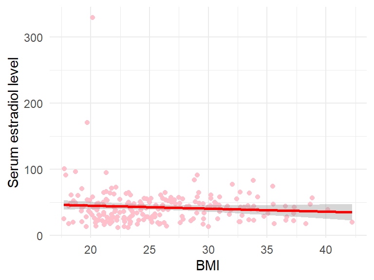

The plot shows the negative correlation between BMI and serum estradiol level. There are two outliers around x=20.

**2. Provide the summary regression output**

```
##
## Call:
## lm(formula = estradl ~ bmi, data = estr_df)
##
## Residuals:
##    Min     1Q Median     3Q    Max
## -32.43 -15.90  -2.21   8.76 284.82
##
## Coefficients:
##             Estimate Std. Error t value Pr(>|t|)
## (Intercept)   54.310      9.505    5.71  3.8e-08 ***
## bmi           -0.453      0.360   -1.26     0.21
## ---
## Signif. codes:  0 '***' 0.001 '**' 0.01 '*' 0.05 '.' 0.1 ' ' 1
##
## Residual standard error: 28.2 on 208 degrees of freedom
## Multiple R-squared:  0.00753,    Adjusted R-squared:  0.00276
## F-statistic: 1.58 on 1 and 208 DF,  p-value: 0.21
```

The slop of the model equals to -0.453 which means: with one unit increase in BMI value, the mean serum estradiol level will decrease 0.453. Both r squared(0.00753) and adjust r squared(0.00276 ) are very small, which indicates that it is not a good model for analyzing. The p value equals to 0.21, which is greater than significant level 0.05. It means that the negative association between BMI and serum estraldio level is not strong, there is no significant evidence to prove the relationship between the two.

### 2.2 How does the relationship between BMI and serum estradiol change after controlling for all the other risk factors listed above?

| term | estimate | std.error | statistic | p.value |
| --- | --- | --- | --- | --- |
| (Intercept) | 26.157 | 13.072 | 2.001 | 0.047 |
| ethnicCaucasian | 16.058 | 4.449 | 3.609 | 0.000 |
| entage | 0.518 | 0.359 | 1.444 | 0.150 |
| numchild | -0.491 | 1.244 | -0.394 | 0.694 |
| agemenar | 0.107 | 0.169 | 0.635 | 0.526 |
| bmi | -0.107 | 0.370 | -0.288 | 0.774 |

### 2.3 Is there any evidence that these relationships vary for African American and Caucasian women?

**1. Use graphical displays and numerical summaries to sustain your conclusion**

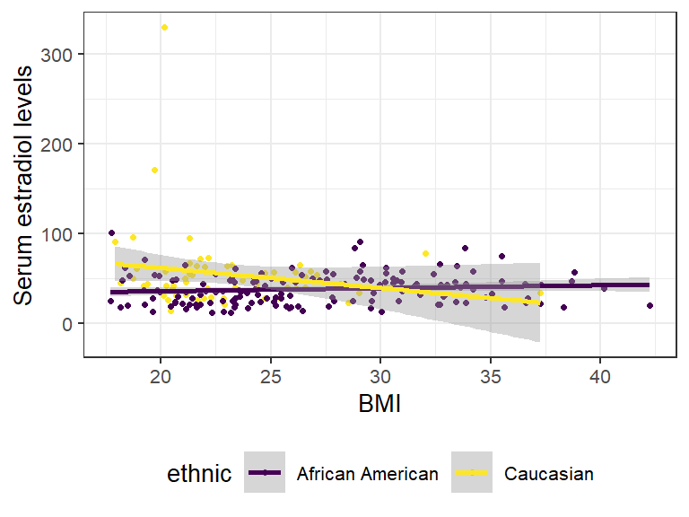

The scatterplot show the relationship between Estradl and BMI in Caucasian and African Ameriacan groups. The Estradl is negative related to BMI in Caucasian group but lightly positive in African American group, which indicate that the relationship is actually varied by ‘ethnic’. The two line cross at BMI approxomately eauql to 30, and there is interaction. The bound of caucasian is wider than African American group.

| ethnic | term | estimate | p_value | conf_low | conf_high |
| --- | --- | --- | --- | --- | --- |
| Caucasian | (Intercept) | 106.285 | 0.004 | 34.78 | 177.785 |
| Caucasian | bmi | -2.235 | 0.147 | -5.28 | 0.809 |
| African American | (Intercept) | 29.075 | 0.000 | 15.56 | 42.589 |
| African American | bmi | 0.333 | 0.184 | -0.16 | 0.826 |

Since there is interaction between the two groups, We make two stratum, fiting two regression modules by the groups. The estimate slope is -2.235 with a p value of 0.147 in the Caucasian group. For one unit increase of BMI, the expected Estradl will decrease 2.235 on average. The estimate slope is 0.333 with a p value of 0.184 in the African American group. For one unit increase of BMI, the expected Estradl will increase 0.333 on average. The different coeffitients strengthens the findings we observed from the scatterplot.

**2. Quantify the relationship between BMI and serum estradiol by ethnicity**

if ethnic is not a predictor:

```
##
## Call:
## lm(formula = estradl ~ bmi, data = estr_df)
##
## Residuals:
##    Min     1Q Median     3Q    Max
## -32.43 -15.90  -2.21   8.76 284.82
##
## Coefficients:
##             Estimate Std. Error t value Pr(>|t|)
## (Intercept)   54.310      9.505    5.71  3.8e-08 ***
## bmi           -0.453      0.360   -1.26     0.21
## ---
## Signif. codes:  0 '***' 0.001 '**' 0.01 '*' 0.05 '.' 0.1 ' ' 1
##
## Residual standard error: 28.2 on 208 degrees of freedom
## Multiple R-squared:  0.00753,    Adjusted R-squared:  0.00276
## F-statistic: 1.58 on 1 and 208 DF,  p-value: 0.21
```

if ethinic is a predictor:

```
##
## Call:
## lm(formula = estradl ~ bmi + ethnic, data = estr_df)
##
## Residuals:
##    Min     1Q Median     3Q    Max
## -40.56 -15.24  -3.58   9.72 275.43
##
## Coefficients:
##                 Estimate Std. Error t value Pr(>|t|)
## (Intercept)      39.1054    10.1042    3.87  0.00015 ***
## bmi              -0.0412     0.3673   -0.11  0.91090
## ethnicCaucasian  16.2967     4.4096    3.70  0.00028 ***
## ---
## Signif. codes:  0 '***' 0.001 '**' 0.01 '*' 0.05 '.' 0.1 ' ' 1
##
## Residual standard error: 27.4 on 207 degrees of freedom
## Multiple R-squared:  0.069,  Adjusted R-squared:  0.06
## F-statistic: 7.67 on 2 and 207 DF,  p-value: 0.000614
```

- In the model without ethnic as a predictor, the coefficient of bmi equal to -0.453, however, it change to -0.0412 in the model with ethnic as predictor. This great difference in coefficient indicates ethnic is a potential confounder that confounding the relationship between Estradl and BMI.

| term | estimate | std.error | statistic | p.value |
| --- | --- | --- | --- | --- |
| (Intercept) | 29.075 | 10.757 | 2.703 | 0.007 |
| bmi | 0.333 | 0.392 | 0.848 | 0.398 |
| ethnicCaucasian | 77.210 | 24.784 | 3.115 | 0.002 |
| bmi:ethnicCaucasian | -2.568 | 1.029 | -2.497 | 0.013 |

According to the table above, we can observe the coeffitient of the interaction term `bmi:ethnicCaucasian` equal to -2.568, which means it will decrease the value of the response variable. The P value is 0.013, indicating the interaction is significant.